# SASC: Hooke Part 2, Time Series Analysis

April 8, 2026

# Analyzing time series perturbation data with Hooke

Download the data: [Cranial ganglia subset (.RDS)](https://depts.washington.edu/trapnell-lab/software/hooke/all-geno_sensory-cranial-ganglion_neuron_29k_cds.RDS)

### Cell metadata breakdown

Our cell metadata contains information about time, perturbation, statistical metrics, and annotation. Key metadata columns include:

- `timepoint`: The developmental stage in hours post fertilization (hpf) of embryos. Embryos were staged according to landmarks described by [(Kimmel et al. 1995)](https://zfin.org/zf_info/zfbook/stages/index.html). Options are 18, 20, 22, 24, 26, 28, 30, 32, 34, 36, 38, 40, 42, 44, 46, 48, 72, and 96 hpf.
- `expt`: Identifies individual library preparation batches.
- `cell_type_sub`: The finest cell type annotation level.
- `cell_type_broad`: A broader level of cell type annotation than `cell_type_sub`, but still capturing all uniquely identified cell types.
- `tissue`: The tissue type annotation that contains the cell types.
- `germ_layer`: The germ layer of origin for each cell type, if known.
- `gene_target`: The genetic perturbation target. Controls include injected (scrambled) and uninjected embryos. Sibling controls are listed as `ctrl-<target>` for null mutants included in the study.
- `mean_nn_time`: The mean time point of the nearest 15 neighbor cells.
- `embryo`: The individual embryo barcode.
- `temp`: The growth temperature of the embryos; standard conditions are 28C.
- `pseudostage`: Embryo-level staging prediction by cell composition.

### Required packages

The time-series workflow depends on the standard Hooke stack, plus the recommended R package `splines` for spline terms used in the model formula. The chunk below loads the required packages, reads the cranial ganglia subset, and plots the annotated cells so you can see the major cell states included in the downstream analysis.

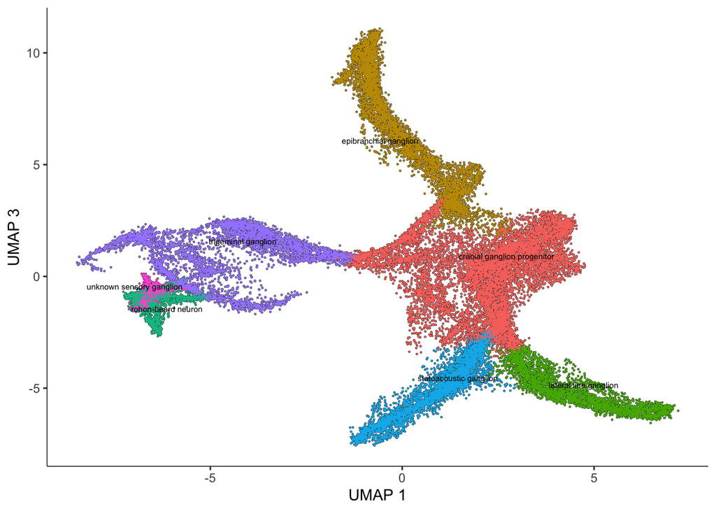

```r
library(monocle3)
library(hooke)
library(tidyverse)
library(splines)
library(ggh4x)

cds <- readRDS("all-geno_sensory-cranial-ganglion_neuron_29k_cds.RDS")

plot_cells(cds, x = 1, y = 3, color_cells_by = "cell_type_sub", label_groups_by_cluster = FALSE, show_trajectory_graph = FALSE)
```

### Fitting a Hooke model with time points

Foxi1 and phox2a are two transcription factors important for cranial sensory ganglia development. Here we subset the `cds` to focus on those perturbations, while retaining the control samples for model fitting. We then create a `cell_count_set`, which is the Hooke object that aggregates cells into sample-by-cell-type counts before model fitting.

```r
control_ids <- unique(colData(cds)$gene_target)[grepl("ctrl-", unique(colData(cds)$gene_target))]

# subset the cds
cds <- cds[, colData(cds)$gene_target %in% c("phox2a", "foxi1", control_ids)]

# code all the controls as "control" and the perturbations by their gene target
colData(cds)$perturbation <- ifelse(
    colData(cds)$gene_target %in% control_ids,
    "control",
    colData(cds)$gene_target
)

# make a hooke cell count set object
ccs <- new_cell_count_set(
    cds,
    sample_group = "embryo",
    cell_group = "cell_type_sub"
)
```

The function `build_interval_formula()` builds a spline-based model formula for time series data. It places knots based on the interval of the data and is a convenient way to construct the time component of the model.

Inputs:

- `ccs`: a Hooke `cell_count_set` object
- `num_breaks`: specifies the degrees of freedom
- `interval_var`: name of the column that the interval should be based on
- `interval_start`: defaults to the minimum of `interval_var`
- `interval_stop`: defaults to the maximum of `interval_var`

Note: use `library(splines)` before fitting the model. Writing `splines::ns()` directly inside the formula string can cause parsing issues in Hooke.

In this example, we model developmental time from 18 to 72 hpf. The resulting formula string represents a smooth, non-linear time effect that can be combined with perturbation status in the count model. You should expect `time_formula` to print a spline-based formula string that can be passed directly into `new_cell_count_model()` as part of the model specification.

```r
start_time <- 18
stop_time <- 72

time_formula <- build_interval_formula(
    ccs,
    num_breaks = 3,
    interval_start = start_time,
    interval_stop = stop_time
)

time_formula
```

```
#> [1] "~ ns( timepoint , knots= c(45) )"
```

This produces a spline-based formula for the time term, which can then be used alongside perturbation status in the model. The next chunk fits a model with both time and perturbation terms, then estimates abundances at a single developmental stage, 48 hpf. This gives a direct contrast at one biologically meaningful timepoint before moving to full trajectory comparisons across the interval. This first `new_cell_count_model()` call is designed for comparing perturbations at a selected timepoint rather than estimating the full time-course kinetics.

```r
ccm <- new_cell_count_model(
    ccs,
    main_model_formula_str = paste0(time_formula, " + perturbation")
)
```

```
#> [1] "fitting model with 1 threads"
```

```r
# Predict abundances for 48 hpf.
cond_wt <- estimate_abundances(
    ccm,
    tibble::tibble(timepoint = 48, perturbation = "control")
)
cond_phox2a <- estimate_abundances(
    ccm,
    tibble::tibble(timepoint = 48, perturbation = "phox2a")
)
cond_foxi1 <- estimate_abundances(
    ccm,
    tibble::tibble(timepoint = 48, perturbation = "foxi1")
)

wt_v_phox2a_tbl <- compare_abundances(ccm, cond_wt, cond_phox2a)
wt_v_foxi1_tbl <- compare_abundances(ccm, cond_wt, cond_foxi1)
```

We can then visualize abundance changes at a selected timepoint. `plot_contrast()` maps those estimated abundance differences back onto the embedding, which makes the most affected cell groups easier to interpret visually. Cell groups with stronger positive or negative shifts indicate perturbation-associated enrichment or depletion at 48 hpf.

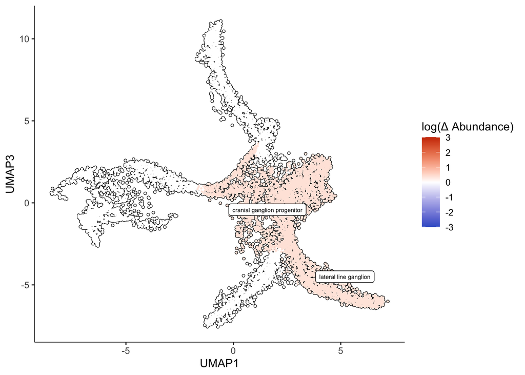

```r
plot_contrast(ccm, wt_v_phox2a_tbl, x = 1, y = 3, q_value_thresh = 0.05)
```

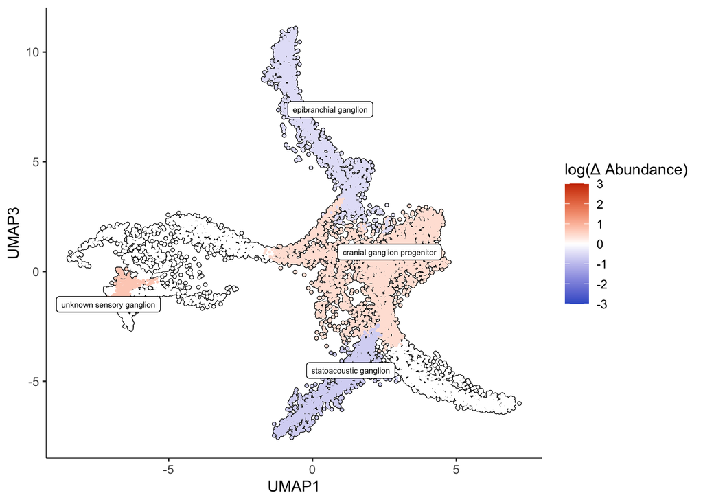

```r
plot_contrast(ccm, wt_v_foxi1_tbl, x = 1, y = 3, q_value_thresh = 0.05)
```

### Using Hooke time intervals to view kinetics

Hooke can also estimate abundances over a time interval to show when cell types reach peak abundance. Here we restrict to control embryos and estimate abundances across time. This control-only analysis gives a baseline view of wild-type developmental kinetics before comparing trajectories from perturbed embryos. That baseline makes it easier to tell whether a perturbation shifts the timing or magnitude of a cell state’s abundance over development.

```r
wt_cds <- cds[, colData(cds)$gene_target %in% control_ids]

wt_ccs <- new_cell_count_set(
    wt_cds,
    sample_group = "embryo",
    cell_group = "cell_type_sub"
)

colData(wt_ccs)$timepoint <- as.numeric(colData(wt_ccs)$timepoint)

wt_ccm <- new_cell_count_model(
    wt_ccs,
    main_model_formula_str = "ns(timepoint, df = 3)"
)
```

```
#> [1] "fitting model with 1 threads"
```

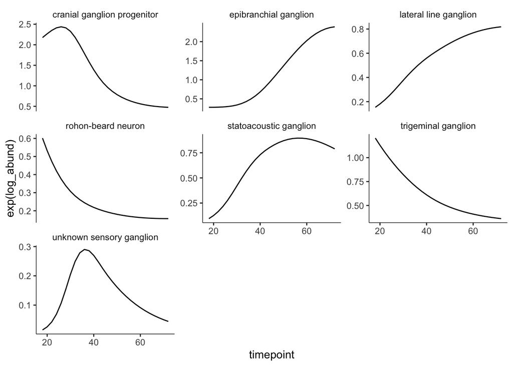

```r
wt_timepoint_pred_df <- estimate_abundances_over_interval(
    wt_ccm,
    interval_start = 18,
    interval_stop = 72,
    interval_col = "timepoint",
    interval_step = 2
)


ggplot(wt_timepoint_pred_df, aes(x = timepoint)) +
    geom_line(aes(y = exp(log_abund))) +
    facet_wrap(~cell_group, scales = "free_y") +
    monocle3:::monocle_theme_opts()
```

### Controlling for batch effects

If the dataset was collected across multiple experiments or batches, include a `nuisance_model_formula_str` and then estimate kinetics separately by batch. This lets you account for experiment-level variation without treating batch as the biological signal of interest. In practice, adding `expt` as a nuisance term means the model adjusts for batch-level differences, so predictions must then be generated with a specific experiment value in `newdata`.

```r
wt_expt_ccm <- new_cell_count_model(
    wt_ccs,
    main_model_formula_str = "ns(timepoint, df = 3)",
    nuisance_model_formula_str = "~ expt"
)
```

```
#> [1] "fitting model with 1 threads"
```

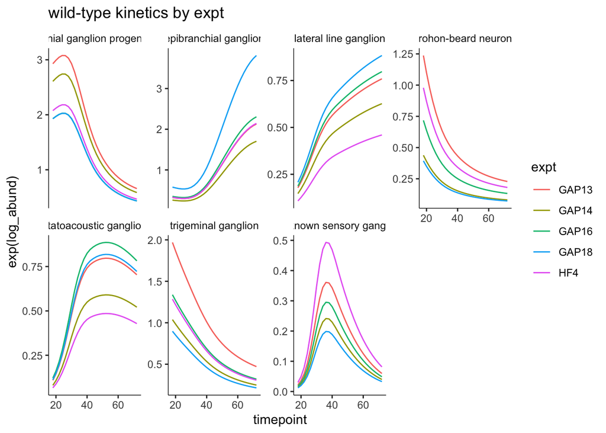

```r
batches <- data.frame(expt = unique(colData(wt_ccs)$expt))

batches <- batches %>%
    dplyr::mutate(
        tp_preds = purrr::map(
            expt,
            ~ estimate_abundances_over_interval(
                wt_expt_ccm,
                interval_start = start_time,
                interval_stop = stop_time,
                interval_col = "timepoint",
                interval_step = 2,
                newdata = tibble::tibble(expt = .x)
            )
        )
    )

wt_timepoint_pred_df <- batches %>%
    dplyr::select(tp_preds) %>%
    tidyr::unnest(tp_preds)

ggplot(wt_timepoint_pred_df, aes(x = timepoint)) +
    geom_line(
        aes(
            y = exp(log_abund),
            color = expt
        )
    ) +
    facet_wrap(~cell_group, scales = "free_y", nrow = 2) +
    monocle3:::monocle_theme_opts() +
    ggtitle("wild-type kinetics by expt")
```

### Perturbation kinetics

We can also compare a perturbation’s kinetics directly against wild type across the time interval. Because `cds` was previously subset to `phox2a` and `foxi1`, we reload the full cranial ganglia dataset here so we can analyze a different perturbation, `tfap2a-foxd3`, against the same control set.

```r
# reload the full dataset before analyzing a different perturbation
cds <- readRDS("all-geno_sensory-cranial-ganglion_neuron_29k_cds.RDS")
tfap2afoxd3_cds <- cds[, colData(cds)$gene_target %in% c("tfap2a-foxd3", control_ids)]

colData(tfap2afoxd3_cds)$perturbation <- ifelse(
    colData(tfap2afoxd3_cds)$gene_target %in% control_ids,
    "control",
    colData(tfap2afoxd3_cds)$gene_target
)

tfap2afoxd3_ccs <- new_cell_count_set(
    tfap2afoxd3_cds,
    sample_group = "embryo",
    cell_group = "cell_type_sub"
)

colData(tfap2afoxd3_ccs)$timepoint <- as.numeric(colData(tfap2afoxd3_ccs)$timepoint)

time_formula <- build_interval_formula(
    tfap2afoxd3_ccs,
    num_breaks = 3,
    interval_start = start_time,
    interval_stop = stop_time
)

tfap2afoxd3_ccm <- new_cell_count_model(
    tfap2afoxd3_ccs,
    main_model_formula_str = paste0(time_formula, " * perturbation")
)
```

```
#> [1] "fitting model with 1 threads"
```

```r
# estimate abundances across the time interval separately for control and tfap2a-foxd3
wt_timepoint_pred_df <- estimate_abundances_over_interval(
    tfap2afoxd3_ccm,
    interval_start = start_time,
    interval_stop = stop_time,
    interval_col = "timepoint",
    interval_step = 2,
    newdata = tibble::tibble(perturbation = "control")
)

ko_timepoint_pred_df <- estimate_abundances_over_interval(
    tfap2afoxd3_ccm,
    interval_start = start_time,
    interval_stop = stop_time,
    interval_col = "timepoint",
    interval_step = 2,
    newdata = tibble::tibble(perturbation = "tfap2a-foxd3")
)

timepoints <- seq(start_time, stop_time, 2)

# compare the two conditions at each timepoint
perturb_vs_wt_nodes <- tibble::tibble(t1 = timepoints) %>%
    dplyr::mutate(
        comp_abund = purrr::map(
            t1,
            compare_ko_to_wt_at_timepoint,
            perturbation_ccm = tfap2afoxd3_ccm,
            interval_col = "timepoint",
            wt_pred_df = wt_timepoint_pred_df,
            ko_pred_df = ko_timepoint_pred_df
        )
    ) %>%
    tidyr::unnest(comp_abund)
```

The final plot overlays the wild-type and perturbation trajectories. The shaded difference layer highlights where the two predicted abundance curves diverge across developmental time.

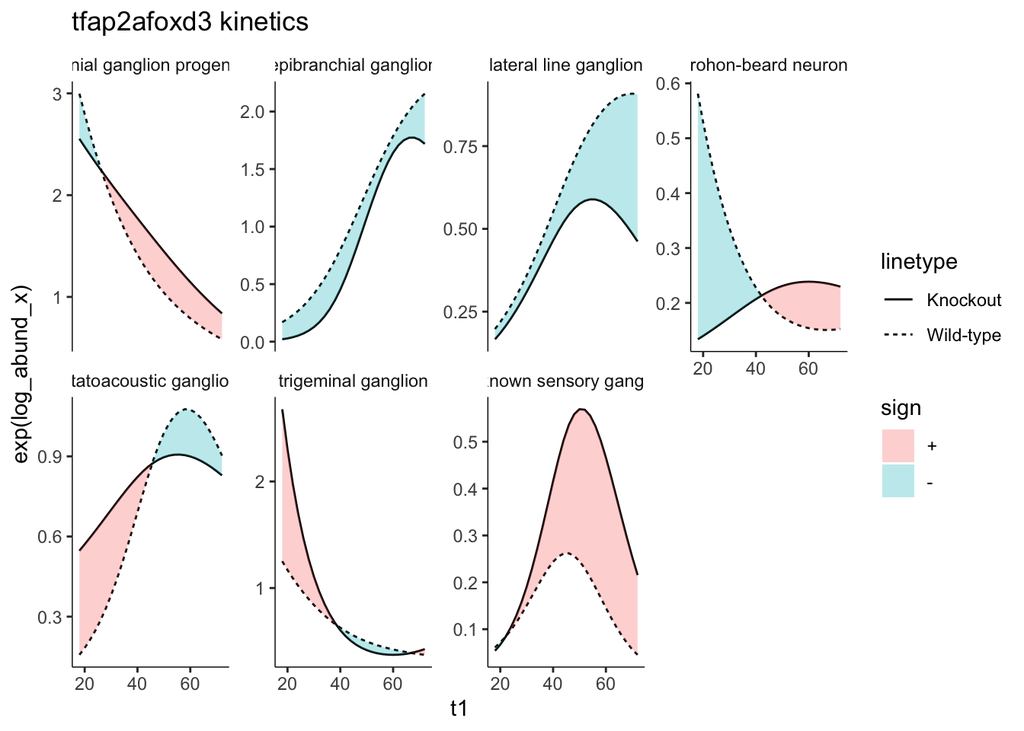

```r
ggplot(perturb_vs_wt_nodes, aes(x = t1)) +
    geom_line(
        aes(
            y = exp(log_abund_x),
            linetype = "Wild-type"
        )
    ) +
    geom_line(
        aes(
            y = exp(log_abund_y),
            linetype = "Knockout"
        )
    ) +
    ggh4x::stat_difference(
        aes(
            ymin = exp(log_abund_x),
            ymax = exp(log_abund_y)
        ),
        alpha = 0.3
    ) +
    facet_wrap(~cell_group, scales = "free_y", nrow = 2) +
    monocle3:::monocle_theme_opts() +
    ggtitle("tfap2afoxd3 kinetics")
```